# Market Basket Analysis of Online Retail Transactions

Apriori and Association Rule Mining on the UCI Online Retail dataset

Data Warehousing & Data Mining

24 August 2026

```r
# root.dir above already points at the project root, so paths are relative to it
source("R/00_setup.R")

# knitr resolves chunk paths against the document, not against root.dir, so pin
# the output directories to absolute paths before reading anything.
DIR_PROC <- normalizePath("data/processed", winslash = "/", mustWork = TRUE)
DIR_FIG  <- normalizePath("output/figures", winslash = "/", mustWork = TRUE)
DIR_TAB  <- normalizePath("output/tables",  winslash = "/", mustWork = TRUE)

retail    <- readRDS(file.path(DIR_PROC, "retail_clean.rds"))
trans     <- readRDS(file.path(DIR_PROC, "transactions.rds"))
rules     <- readRDS(file.path(DIR_PROC, "rules_significant.rds"))
itemsets  <- readRDS(file.path(DIR_PROC, "itemsets.rds"))

tab <- function(name) read.csv(file.path(DIR_TAB, paste0(name, ".csv")))
# rel_path = FALSE keeps the absolute path; pandoc embeds the PNG in the HTML
fig <- function(name) knitr::include_graphics(file.path(DIR_FIG, paste0(name, ".png")),
                                             rel_path = FALSE)
```

# 1 Introduction

**Objective.** Discover which products customers of a UK online gift retailer buy *together*, and convert those co-occurrence patterns into actionable merchandising rules.

**Dataset.** UCI Machine Learning Repository #352, *Online Retail* — every transaction of a UK-based, registered, non-store online retailer between **1 December 2010 and 9 December 2011**. The company mainly sells unique all-occasion giftware; many customers are wholesalers.

| Attribute | Meaning |
| --- | --- |
| `InvoiceNo` | Transaction ID. A leading `C` marks a cancellation. |
| `StockCode` | Product code. |
| `Description` | Product name. |
| `Quantity` | Units of the product on that invoice line. |
| `InvoiceDate` | Timestamp of the transaction. |
| `UnitPrice` | Unit price in GBP. |
| `CustomerID` | Customer number (often missing). |
| `Country` | Country of the customer. |

**Method.** The Apriori algorithm (Agrawal & Srikant, 1994) as implemented in the R package `arules`, with rule visualisation from `arulesViz`.

## 1.1 The three measures

For an association rule $X \Rightarrow Y$ over a set of $N$ transactions:

$$\text{support}(X \Rightarrow Y) = P(X \cup Y) = \frac{|\{t : X \cup Y
\subseteq t\}|}{N}$$

$$\text{confidence}(X \Rightarrow Y) = P(Y \mid X) =
\frac{\text{support}(X \cup Y)}{\text{support}(X)}$$

$$\text{lift}(X \Rightarrow Y) = \frac{\text{confidence}(X \Rightarrow
Y)}{\text{support}(Y)} = \frac{P(X \cup Y)}{P(X)P(Y)}$$

- **Support** — how common the pattern is. Governs whether a rule is worth acting on at all.
- **Confidence** — how reliable it is. High confidence alone is misleading when $Y$ is a bestseller bought by nearly everyone.
- **Lift** — how much better than chance. $\text{lift} = 1$ means independence, $> 1$ means the products genuinely attract each other, $< 1$ means they repel.

**The Apriori property**, which makes the search tractable: *every subset of a frequent itemset is itself frequent*. Equivalently, if an itemset is infrequent, every superset of it is infrequent too and can be pruned without being counted. Without this, mining 3,765 distinct products would mean evaluating $2^{3765}$ candidate itemsets.

# 2 Data preparation

## 2.1 Quality audit of the raw file

```r
knitr::kable(tab("01_data_quality_audit"), format.args = list(big.mark = ","))
```

| Check | Value |
| --- | --- |
| Total rows | 541,909 |
| Missing Description | 1,454 |
| Missing CustomerID | 135,080 |
| Cancelled invoices (InvoiceNo starts with ‘C’) | 9,288 |
| Quantity <= 0 | 10,624 |
| UnitPrice <= 0 | 2,517 |
| Duplicate rows | 5,268 |
| Distinct invoices | 25,900 |
| Distinct stock codes | 4,070 |
| Distinct countries | 38 |

Four problems had to be resolved before mining:

1. **Cancellations** (`InvoiceNo` starting with `C`) and **negative quantities** are returns, not purchases. Leaving them in would fabricate co-occurrences that never happened.
2. **Zero or negative unit prices** are adjustments and free samples.
3. **Non-product stock codes** (`POST`, `DOT`, `M`, `BANK CHARGES`, `AMAZONFEE`, …) are postage and administrative lines. They appear on a huge share of invoices, so they would dominate every rule while carrying no merchandising meaning.
4. **Free-text junk descriptions** (“damaged”, “check”, “?”, “found”, “lost”) are warehouse notes, not products.

Additionally, each `StockCode` was pinned to a single canonical description (descriptions drift across rows for the same product), duplicate item lines within an invoice were collapsed, and **single-item baskets were dropped** — a basket of one contains no co-occurrence information and only dilutes support.

## 2.2 Result

```r
knitr::kable(tab("01_cleaning_summary"))
```

| Metric | Value |
| --- | --- |
| Rows after cleaning | 515,784 |
| Rows removed | 26,125 |
| % rows retained | 95.2% |
| Transactions (baskets) | 18,273 |
| Unique products | 3,765 |
| Countries | 38 |
| Date range | 2010-12-01 to 2011-12-09 |
| Mean basket size | 28.23 |
| Median basket size | 17 |
| Total revenue (GBP) | 9,658,813 |

# 3 Exploratory analysis

## 3.1 What sells most often

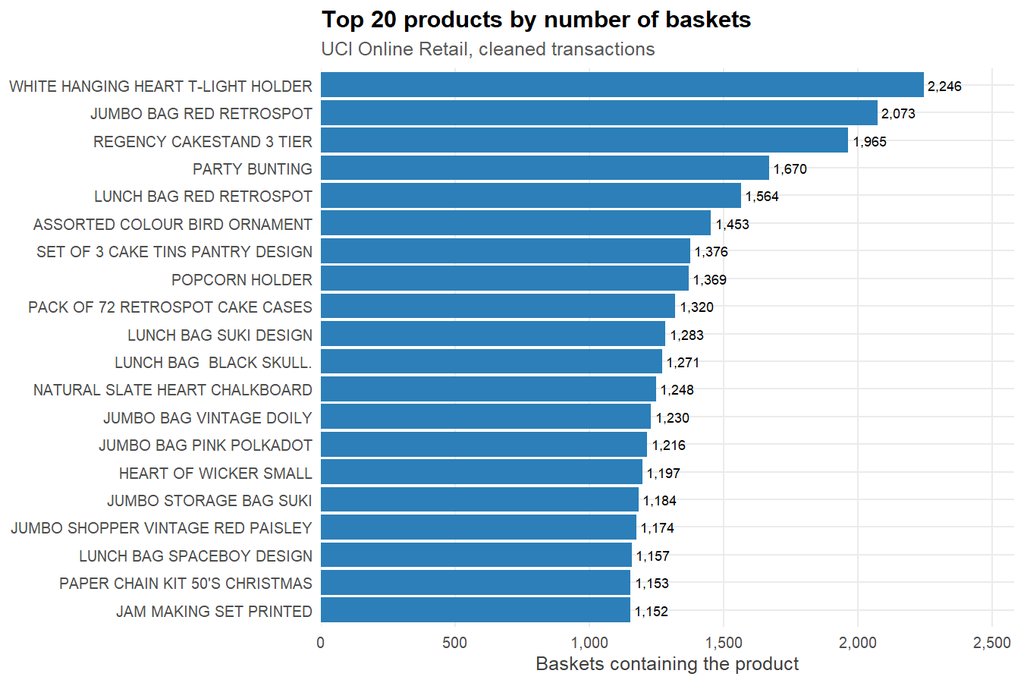

```r
fig("01_top_items_frequency")
```

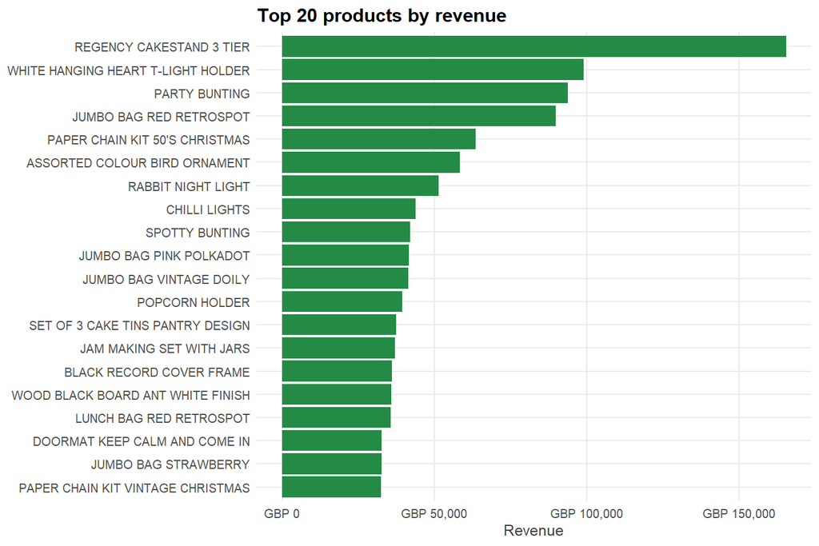

```r
fig("02_top_items_revenue")
```

## 3.2 Basket size

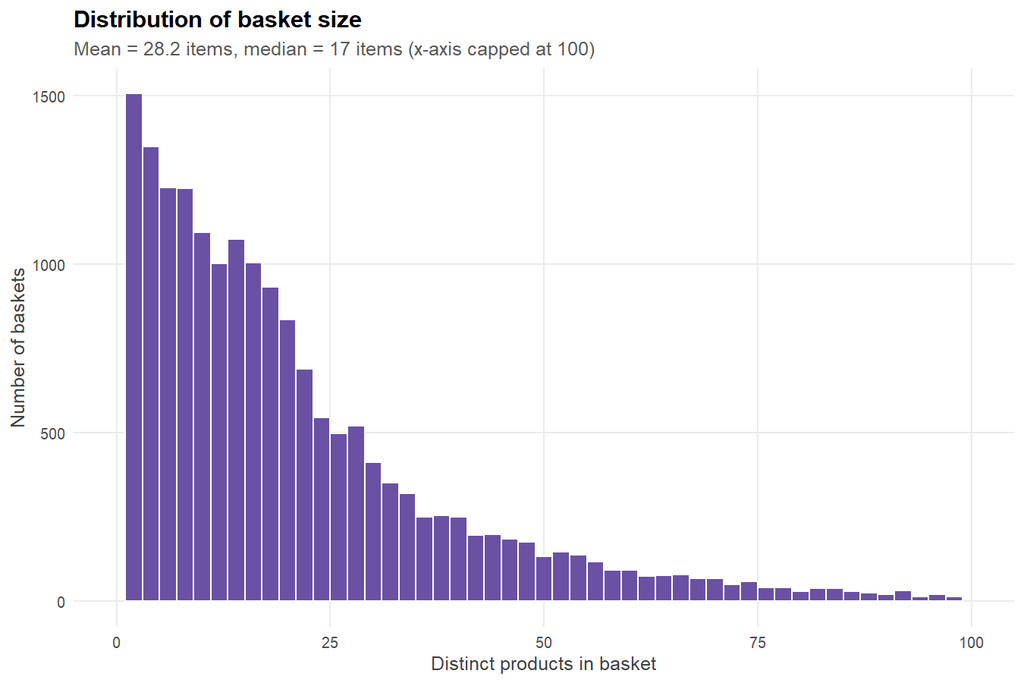

```r
fig("03_basket_size_distribution")
```

```r
knitr::kable(tab("02_basket_size_stats"))
```

| Statistic | BasketSize |
| --- | --- |
| Min | 2.00 |
| Q1 | 8.00 |
| Median | 17.00 |
| Mean | 28.23 |
| Q3 | 30.00 |
| P95 | 78.40 |
| Max | 1106.00 |

The distribution is heavily right-skewed. The long tail is the wholesale customers — baskets of a hundred or more distinct products. These large baskets generate an enormous number of item pairs and are the main reason support values in this dataset stay low even for strong rules.

## 3.3 Time and geography

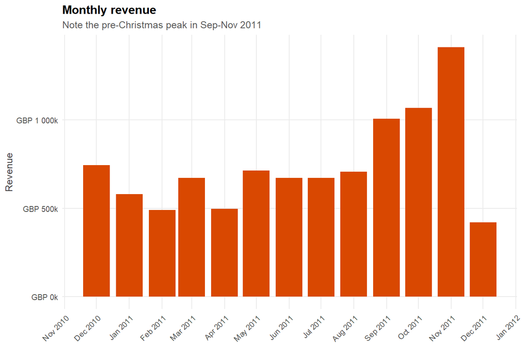

```r
fig("04_monthly_revenue")
```

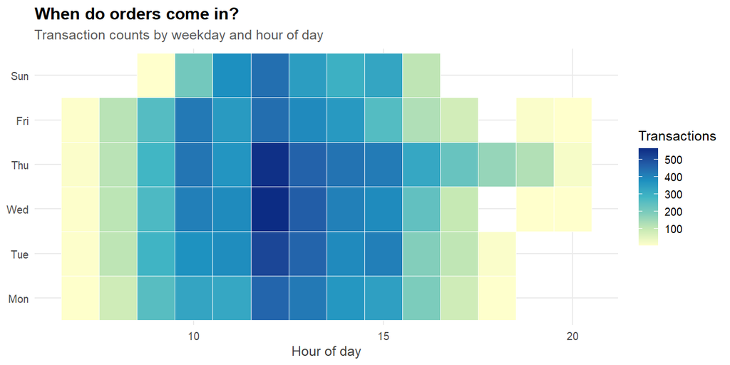

```r
fig("05_weekday_hour_heatmap")
```

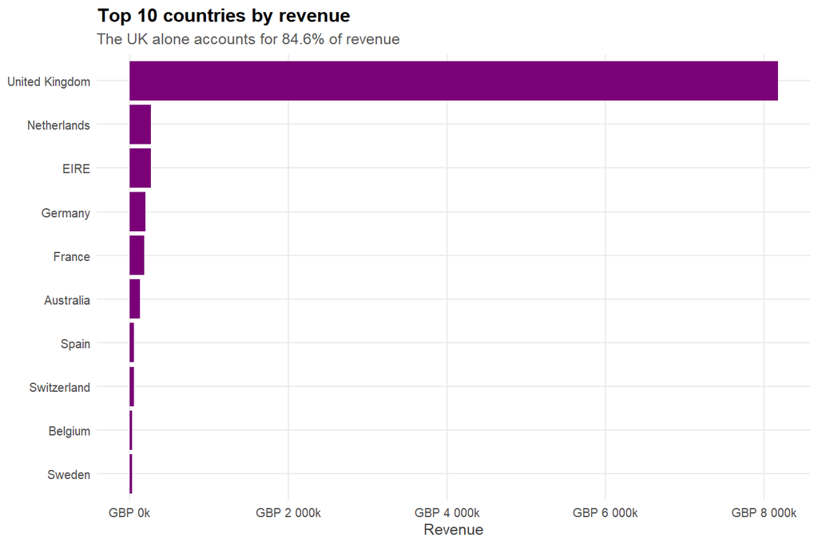

```r
fig("06_top_countries")
```

Three operational facts fall out: revenue peaks sharply in the pre-Christmas quarter (September–November), trading is concentrated on weekday business hours with essentially no Saturday activity, and the UK dominates revenue while the Netherlands, Ireland and Germany form a meaningful second tier.

# 4 Apriori: frequent itemsets

## 4.1 The transaction object

```r
summary(trans)
```

```
## transactions as itemMatrix in sparse format with
##  18273 rows (elements/itemsets/transactions) and
##  3765 columns (items) and a density of 0.007492866
##
## most frequent items:
## WHITE HANGING HEART T-LIGHT HOLDER            JUMBO BAG RED RETROSPOT
##                               2246                               2073
##           REGENCY CAKESTAND 3 TIER                      PARTY BUNTING
##                               1965                               1670
##            LUNCH BAG RED RETROSPOT                            (Other)
##                               1564                             505975
##
## element (itemset/transaction) length distribution:
## sizes
##    2    3    4    5    6    7    8    9   10   11   12   13   14   15   16   17
```

[output cut: 60 more lines]

Density is around 0.75%, i.e. the average basket touches under 1% of the catalogue. Extreme sparsity is normal in retail and is exactly the condition Apriori’s pruning is designed for.

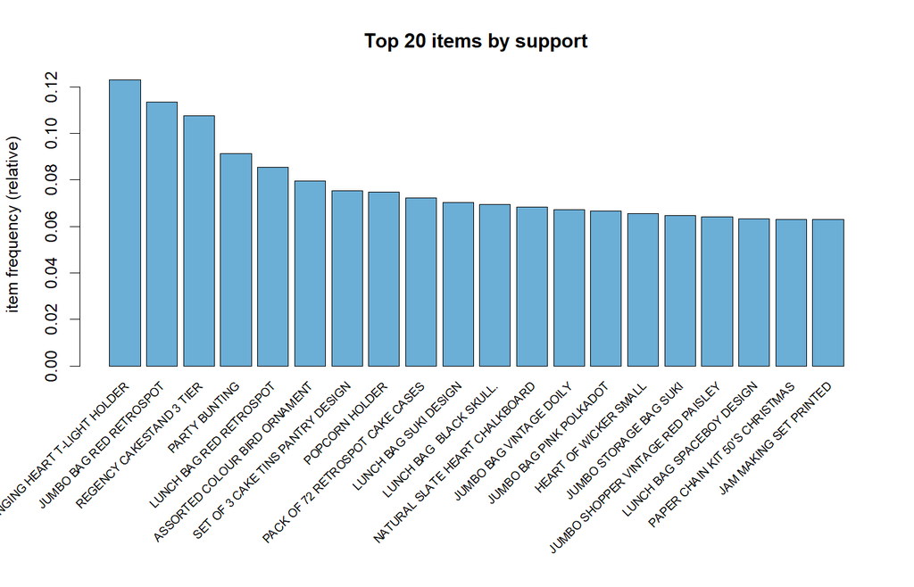

```r
fig("07_item_frequency_relative")
```

## 4.2 Frequent itemsets at 1% support

```r
knitr::kable(tab("03_frequent_itemset_counts"),
             col.names = c("Itemset size (k)", "Frequent itemsets found"))
```

| Itemset size (k) | Frequent itemsets found |
| --- | --- |
| 1 | 898 |
| 2 | 1192 |
| 3 | 389 |
| 4 | 45 |

```r
knitr::kable(head(tab("03_top_multi_item_itemsets"), 15))
```

| Itemset | Size | Support | Count |
| --- | --- | --- | --- |
| {JUMBO BAG PINK POLKADOT,JUMBO BAG RED RETROSPOT} | 2 | 0.04515 | 825 |
| {GREEN REGENCY TEACUP AND SAUCER,ROSES REGENCY TEACUP AND SAUCER} | 2 | 0.04197 | 767 |
| {JUMBO BAG RED RETROSPOT,JUMBO STORAGE BAG SUKI} | 2 | 0.03962 | 724 |
| {JUMBO BAG RED RETROSPOT,JUMBO SHOPPER VINTAGE RED PAISLEY} | 2 | 0.03721 | 680 |
| {LUNCH BAG RED RETROSPOT,LUNCH BAG SUKI DESIGN} | 2 | 0.03585 | 655 |
| {LUNCH BAG BLACK SKULL.,LUNCH BAG RED RETROSPOT} | 2 | 0.03508 | 641 |
| {ALARM CLOCK BAKELIKE GREEN,ALARM CLOCK BAKELIKE RED} | 2 | 0.03502 | 640 |
| {GREEN REGENCY TEACUP AND SAUCER,PINK REGENCY TEACUP AND SAUCER} | 2 | 0.03459 | 632 |
| {LUNCH BAG PINK POLKADOT,LUNCH BAG RED RETROSPOT} | 2 | 0.03316 | 606 |
| {PINK REGENCY TEACUP AND SAUCER,ROSES REGENCY TEACUP AND SAUCER} | 2 | 0.03273 | 598 |
| {JUMBO BAG BAROQUE BLACK WHITE,JUMBO BAG RED RETROSPOT} | 2 | 0.03201 | 585 |
| {LUNCH BAG BLACK SKULL.,LUNCH BAG SUKI DESIGN} | 2 | 0.03196 | 584 |
| {JUMBO BAG RED RETROSPOT,LUNCH BAG RED RETROSPOT} | 2 | 0.03169 | 579 |
| {JUMBO BAG RED RETROSPOT,JUMBO BAG VINTAGE DOILY} | 2 | 0.03158 | 577 |
| {LUNCH BAG RED RETROSPOT,LUNCH BAG SPACEBOY DESIGN} | 2 | 0.03065 | 560 |

# 5 Association rules

## 5.1 Parameters and the pipeline of filters

```r
knitr::kable(data.frame(
  Parameter = c("Minimum support", "Minimum confidence", "Rule length",
                "Minimum lift", "Significance test"),
  Value = c(paste0(PARAMS$support * 100, "% (about ",
                   round(PARAMS$support * length(trans)), " baskets)"),
            paste0(PARAMS$confidence * 100, "%"),
            paste(PARAMS$minlen, "to", PARAMS$maxlen, "items"),
            paste(">", PARAMS$min_lift),
            "Fisher's exact test, Benjamini-Hochberg adjusted, p < 0.05")))
```

| Parameter | Value |
| --- | --- |
| Minimum support | 1% (about 183 baskets) |
| Minimum confidence | 30% |
| Rule length | 2 to 4 items |
| Minimum lift | > 1 |
| Significance test | Fisher’s exact test, Benjamini-Hochberg adjusted, p < 0.05 |

Rules were filtered in four stages:

1. **Apriori** with the support and confidence floors above.
2. **Lift > 1** — discard rules no better than chance.
3. **Redundancy removal** (`is.redundant`) — a rule is redundant when a *more general* rule (a subset of its antecedent) achieves at least the same confidence. The extra condition earns nothing and only clutters the output.
4. **Statistical significance** — Fisher’s exact test on each rule’s 2×2 contingency table, with Benjamini–Hochberg correction for the fact that thousands of rules are being tested at once.

2215 rules survive all four stages.

## 5.2 The rule landscape

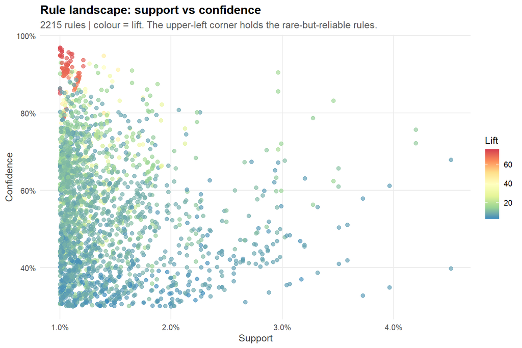

```r
fig("09_rules_scatter")
```

```r
fig("10_rules_two_key")
```

[output not shown]

The scatter shows the classic trade-off. Rules in the upper-left are rare but almost deterministic; rules on the right are common but weaker. There is no single “best” corner — which one matters depends on whether you are designing a homepage widget (needs support) or a checkout prompt (needs confidence).

## 5.3 Strongest rules by lift

```r
knitr::kable(tab("03_top_rules_by_lift"))
```

| Antecedent_LHS | Consequent_RHS | support | confidence | coverage | lift | count | fishersPValue | pAdjusted |
| --- | --- | --- | --- | --- | --- | --- | --- | --- |
| HERB MARKER MINT + HERB MARKER PARSLEY | HERB MARKER CHIVES | 0.01001 | 0.86321 | 0.01160 | 75.47077 | 183 | 0 | 0 |
| HERB MARKER PARSLEY + HERB MARKER THYME | HERB MARKER CHIVES | 0.01001 | 0.85915 | 0.01166 | 75.11645 | 183 | 0 | 0 |
| HERB MARKER PARSLEY + HERB MARKER ROSEMARY | HERB MARKER CHIVES | 0.01001 | 0.85116 | 0.01177 | 74.41769 | 183 | 0 | 0 |
| HERB MARKER CHIVES + HERB MARKER THYME | HERB MARKER PARSLEY | 0.01001 | 0.96825 | 0.01034 | 74.33994 | 183 | 0 | 0 |
| HERB MARKER CHIVES + HERB MARKER ROSEMARY | HERB MARKER PARSLEY | 0.01001 | 0.96825 | 0.01034 | 74.33994 | 183 | 0 | 0 |
| HERB MARKER BASIL + HERB MARKER PARSLEY + HERB MARKER ROSEMARY | HERB MARKER THYME | 0.01018 | 0.95876 | 0.01062 | 74.23506 | 186 | 0 | 0 |
| HERB MARKER CHIVES + HERB MARKER MINT | HERB MARKER PARSLEY | 0.01001 | 0.96316 | 0.01040 | 73.94867 | 183 | 0 | 0 |
| HERB MARKER MINT + HERB MARKER PARSLEY + HERB MARKER ROSEMARY | HERB MARKER THYME | 0.01018 | 0.94898 | 0.01073 | 73.47756 | 186 | 0 | 0 |
| HERB MARKER CHIVES + HERB MARKER PARSLEY | HERB MARKER THYME | 0.01001 | 0.94819 | 0.01056 | 73.41615 | 183 | 0 | 0 |
| HERB MARKER BASIL + HERB MARKER PARSLEY + HERB MARKER THYME | HERB MARKER ROSEMARY | 0.01018 | 0.96373 | 0.01056 | 73.37604 | 186 | 0 | 0 |
| HERB MARKER PARSLEY + HERB MARKER ROSEMARY | HERB MARKER THYME | 0.01111 | 0.94419 | 0.01177 | 73.10641 | 203 | 0 | 0 |
| HERB MARKER MINT + HERB MARKER PARSLEY + HERB MARKER THYME | HERB MARKER ROSEMARY | 0.01018 | 0.95876 | 0.01062 | 72.99781 | 186 | 0 | 0 |
| HERB MARKER MINT + HERB MARKER THYME | HERB MARKER ROSEMARY | 0.01078 | 0.95631 | 0.01127 | 72.81110 | 197 | 0 | 0 |
| HERB MARKER PARSLEY + HERB MARKER THYME | HERB MARKER ROSEMARY | 0.01111 | 0.95305 | 0.01166 | 72.56297 | 203 | 0 | 0 |
| HERB MARKER BASIL + HERB MARKER THYME | HERB MARKER ROSEMARY | 0.01095 | 0.95238 | 0.01149 | 72.51190 | 200 | 0 | 0 |
| HERB MARKER MINT + HERB MARKER ROSEMARY + HERB MARKER THYME | HERB MARKER PARSLEY | 0.01018 | 0.94416 | 0.01078 | 72.49025 | 186 | 0 | 0 |
| HERB MARKER BASIL + HERB MARKER ROSEMARY | HERB MARKER THYME | 0.01095 | 0.93458 | 0.01171 | 72.36259 | 200 | 0 | 0 |
| HERB MARKER MINT + HERB MARKER THYME | HERB MARKER PARSLEY | 0.01062 | 0.94175 | 0.01127 | 72.30485 | 194 | 0 | 0 |
| HERB MARKER CHIVES + HERB MARKER PARSLEY | HERB MARKER MINT | 0.01001 | 0.94819 | 0.01056 | 72.19255 | 183 | 0 | 0 |
| HERB MARKER CHIVES + HERB MARKER PARSLEY | HERB MARKER ROSEMARY | 0.01001 | 0.94819 | 0.01056 | 72.19255 | 183 | 0 | 0 |

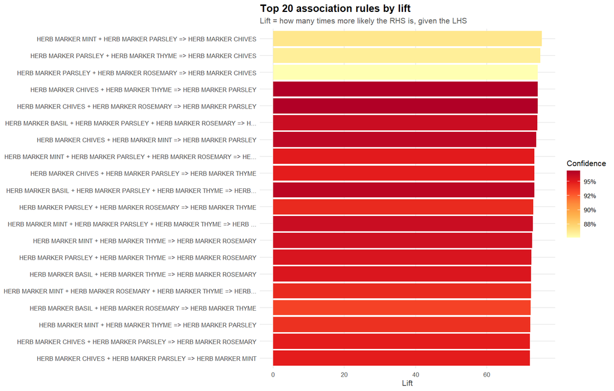

```r
fig("14_top_rules_by_lift_bars")
```

## 5.4 Strongest rules by confidence

```r
knitr::kable(tab("03_top_rules_by_confidence"))
```

| Antecedent_LHS | Consequent_RHS | support | confidence | coverage | lift | count | fishersPValue | pAdjusted |
| --- | --- | --- | --- | --- | --- | --- | --- | --- |
| HERB MARKER CHIVES + HERB MARKER THYME | HERB MARKER PARSLEY | 0.01001 | 0.96825 | 0.01034 | 74.33994 | 183 | 0 | 0 |
| HERB MARKER CHIVES + HERB MARKER ROSEMARY | HERB MARKER PARSLEY | 0.01001 | 0.96825 | 0.01034 | 74.33994 | 183 | 0 | 0 |
| HERB MARKER BASIL + HERB MARKER PARSLEY + HERB MARKER THYME | HERB MARKER ROSEMARY | 0.01018 | 0.96373 | 0.01056 | 73.37604 | 186 | 0 | 0 |
| HERB MARKER CHIVES + HERB MARKER MINT | HERB MARKER PARSLEY | 0.01001 | 0.96316 | 0.01040 | 73.94867 | 183 | 0 | 0 |
| HERB MARKER MINT + HERB MARKER PARSLEY + HERB MARKER THYME | HERB MARKER ROSEMARY | 0.01018 | 0.95876 | 0.01062 | 72.99781 | 186 | 0 | 0 |
| HERB MARKER BASIL + HERB MARKER PARSLEY + HERB MARKER ROSEMARY | HERB MARKER THYME | 0.01018 | 0.95876 | 0.01062 | 74.23506 | 186 | 0 | 0 |
| HERB MARKER MINT + HERB MARKER THYME | HERB MARKER ROSEMARY | 0.01078 | 0.95631 | 0.01127 | 72.81110 | 197 | 0 | 0 |
| HERB MARKER PARSLEY + HERB MARKER THYME | HERB MARKER ROSEMARY | 0.01111 | 0.95305 | 0.01166 | 72.56297 | 203 | 0 | 0 |
| HERB MARKER BASIL + HERB MARKER THYME | HERB MARKER ROSEMARY | 0.01095 | 0.95238 | 0.01149 | 72.51190 | 200 | 0 | 0 |
| HERB MARKER MINT + HERB MARKER PARSLEY + HERB MARKER ROSEMARY | HERB MARKER THYME | 0.01018 | 0.94898 | 0.01073 | 73.47756 | 186 | 0 | 0 |
| HERB MARKER CHIVES + HERB MARKER PARSLEY | HERB MARKER MINT | 0.01001 | 0.94819 | 0.01056 | 72.19255 | 183 | 0 | 0 |
| HERB MARKER CHIVES + HERB MARKER PARSLEY | HERB MARKER THYME | 0.01001 | 0.94819 | 0.01056 | 73.41615 | 183 | 0 | 0 |
| HERB MARKER CHIVES + HERB MARKER PARSLEY | HERB MARKER ROSEMARY | 0.01001 | 0.94819 | 0.01056 | 72.19255 | 183 | 0 | 0 |
| REGENCY TEA PLATE PINK + REGENCY TEA PLATE ROSES | REGENCY TEA PLATE GREEN | 0.01396 | 0.94796 | 0.01472 | 45.58418 | 255 | 0 | 0 |
| HERB MARKER PARSLEY + HERB MARKER ROSEMARY | HERB MARKER THYME | 0.01111 | 0.94419 | 0.01177 | 73.10641 | 203 | 0 | 0 |
| HERB MARKER MINT + HERB MARKER ROSEMARY + HERB MARKER THYME | HERB MARKER PARSLEY | 0.01018 | 0.94416 | 0.01078 | 72.49025 | 186 | 0 | 0 |
| HERB MARKER MINT + HERB MARKER THYME | HERB MARKER PARSLEY | 0.01062 | 0.94175 | 0.01127 | 72.30485 | 194 | 0 | 0 |
| HERB MARKER THYME | HERB MARKER ROSEMARY | 0.01209 | 0.93644 | 0.01292 | 71.29825 | 221 | 0 | 0 |
| HERB MARKER BASIL + HERB MARKER ROSEMARY | HERB MARKER THYME | 0.01095 | 0.93458 | 0.01171 | 72.36259 | 200 | 0 | 0 |
| HERB MARKER BASIL + HERB MARKER ROSEMARY + HERB MARKER THYME | HERB MARKER PARSLEY | 0.01018 | 0.93000 | 0.01095 | 71.40290 | 186 | 0 | 0 |

## 5.5 Most frequent rules

```r
knitr::kable(tab("03_top_rules_by_support"))
```

| Antecedent_LHS | Consequent_RHS | support | confidence | coverage | lift | count | fishersPValue | pAdjusted |
| --- | --- | --- | --- | --- | --- | --- | --- | --- |
| JUMBO BAG PINK POLKADOT | JUMBO BAG RED RETROSPOT | 0.04515 | 0.67845 | 0.06655 | 5.98041 | 825 | 0 | 0 |
| JUMBO BAG RED RETROSPOT | JUMBO BAG PINK POLKADOT | 0.04515 | 0.39797 | 0.11345 | 5.98041 | 825 | 0 | 0 |
| ROSES REGENCY TEACUP AND SAUCER | GREEN REGENCY TEACUP AND SAUCER | 0.04197 | 0.72222 | 0.05812 | 13.02781 | 767 | 0 | 0 |
| GREEN REGENCY TEACUP AND SAUCER | ROSES REGENCY TEACUP AND SAUCER | 0.04197 | 0.75716 | 0.05544 | 13.02781 | 767 | 0 | 0 |
| JUMBO STORAGE BAG SUKI | JUMBO BAG RED RETROSPOT | 0.03962 | 0.61149 | 0.06480 | 5.39011 | 724 | 0 | 0 |
| JUMBO BAG RED RETROSPOT | JUMBO STORAGE BAG SUKI | 0.03962 | 0.34925 | 0.11345 | 5.39011 | 724 | 0 | 0 |
| JUMBO SHOPPER VINTAGE RED PAISLEY | JUMBO BAG RED RETROSPOT | 0.03721 | 0.57922 | 0.06425 | 5.10565 | 680 | 0 | 0 |
| JUMBO BAG RED RETROSPOT | JUMBO SHOPPER VINTAGE RED PAISLEY | 0.03721 | 0.32803 | 0.11345 | 5.10565 | 680 | 0 | 0 |
| LUNCH BAG SUKI DESIGN | LUNCH BAG RED RETROSPOT | 0.03585 | 0.51052 | 0.07021 | 5.96469 | 655 | 0 | 0 |
| LUNCH BAG RED RETROSPOT | LUNCH BAG SUKI DESIGN | 0.03585 | 0.41880 | 0.08559 | 5.96469 | 655 | 0 | 0 |
| LUNCH BAG BLACK SKULL. | LUNCH BAG RED RETROSPOT | 0.03508 | 0.50433 | 0.06956 | 5.89231 | 641 | 0 | 0 |
| LUNCH BAG RED RETROSPOT | LUNCH BAG BLACK SKULL. | 0.03508 | 0.40985 | 0.08559 | 5.89231 | 641 | 0 | 0 |
| ALARM CLOCK BAKELIKE RED | ALARM CLOCK BAKELIKE GREEN | 0.03502 | 0.60952 | 0.05746 | 11.42341 | 640 | 0 | 0 |
| ALARM CLOCK BAKELIKE GREEN | ALARM CLOCK BAKELIKE RED | 0.03502 | 0.65641 | 0.05336 | 11.42341 | 640 | 0 | 0 |
| PINK REGENCY TEACUP AND SAUCER | GREEN REGENCY TEACUP AND SAUCER | 0.03459 | 0.83158 | 0.04159 | 15.00044 | 632 | 0 | 0 |
| GREEN REGENCY TEACUP AND SAUCER | PINK REGENCY TEACUP AND SAUCER | 0.03459 | 0.62389 | 0.05544 | 15.00044 | 632 | 0 | 0 |
| LUNCH BAG PINK POLKADOT | LUNCH BAG RED RETROSPOT | 0.03316 | 0.55647 | 0.05960 | 6.50156 | 606 | 0 | 0 |
| LUNCH BAG RED RETROSPOT | LUNCH BAG PINK POLKADOT | 0.03316 | 0.38747 | 0.08559 | 6.50156 | 606 | 0 | 0 |
| PINK REGENCY TEACUP AND SAUCER | ROSES REGENCY TEACUP AND SAUCER | 0.03273 | 0.78684 | 0.04159 | 13.53857 | 598 | 0 | 0 |
| ROSES REGENCY TEACUP AND SAUCER | PINK REGENCY TEACUP AND SAUCER | 0.03273 | 0.56309 | 0.05812 | 13.53857 | 598 | 0 | 0 |

## 5.6 Rules as a network

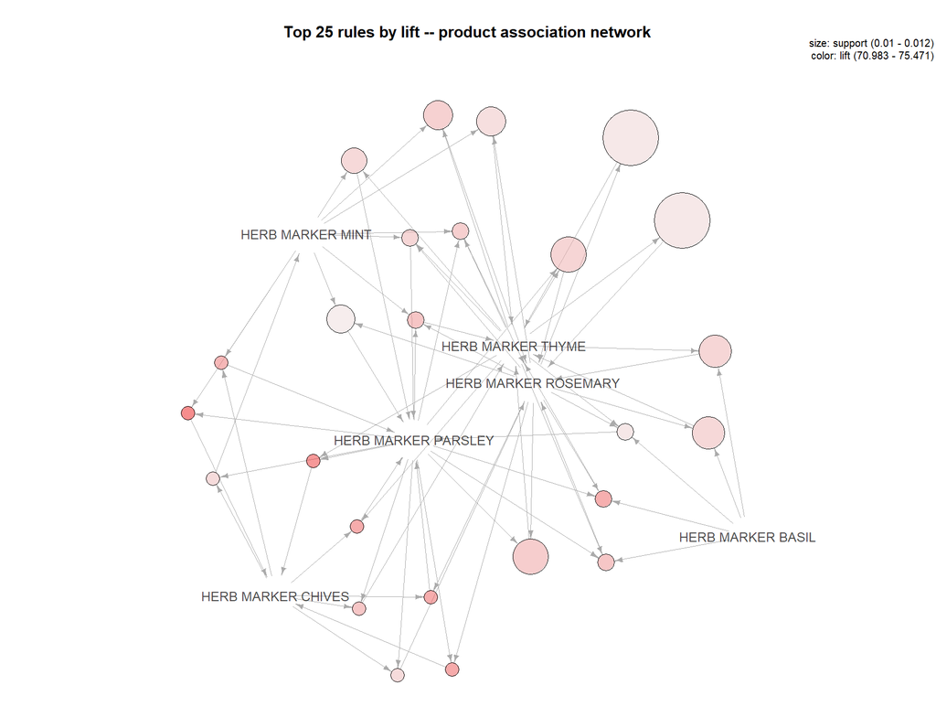

```r
fig("11_rules_graph_top25_lift")
```

```r
fig("12_rules_grouped_matrix")
```

[output not shown]

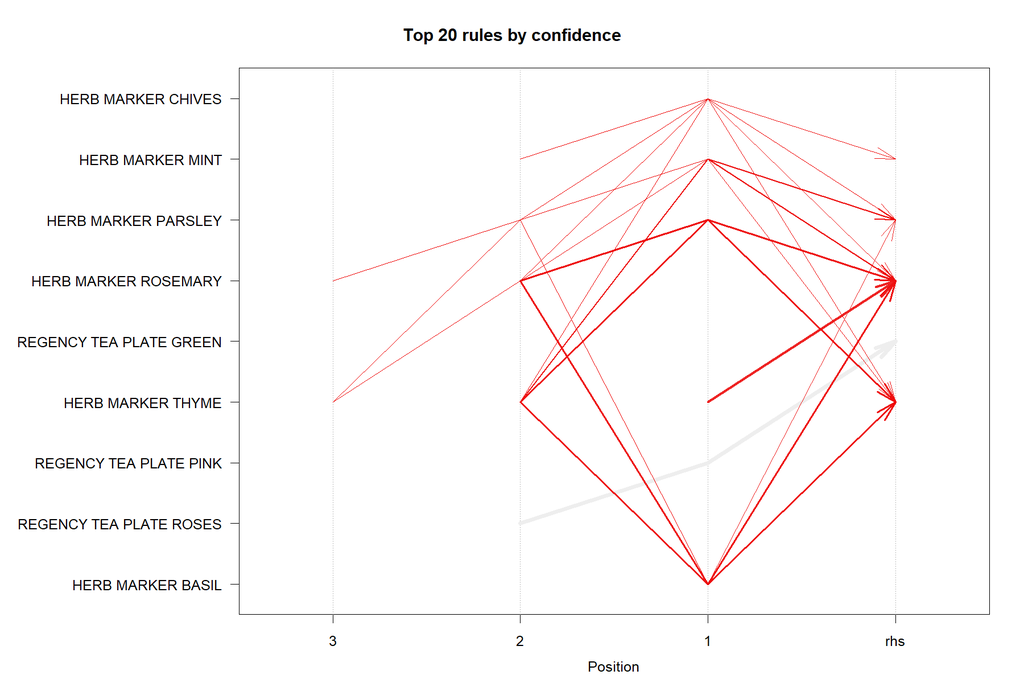

```r
fig("13_rules_paracoord")
```

## 5.7 Sensitivity to the thresholds

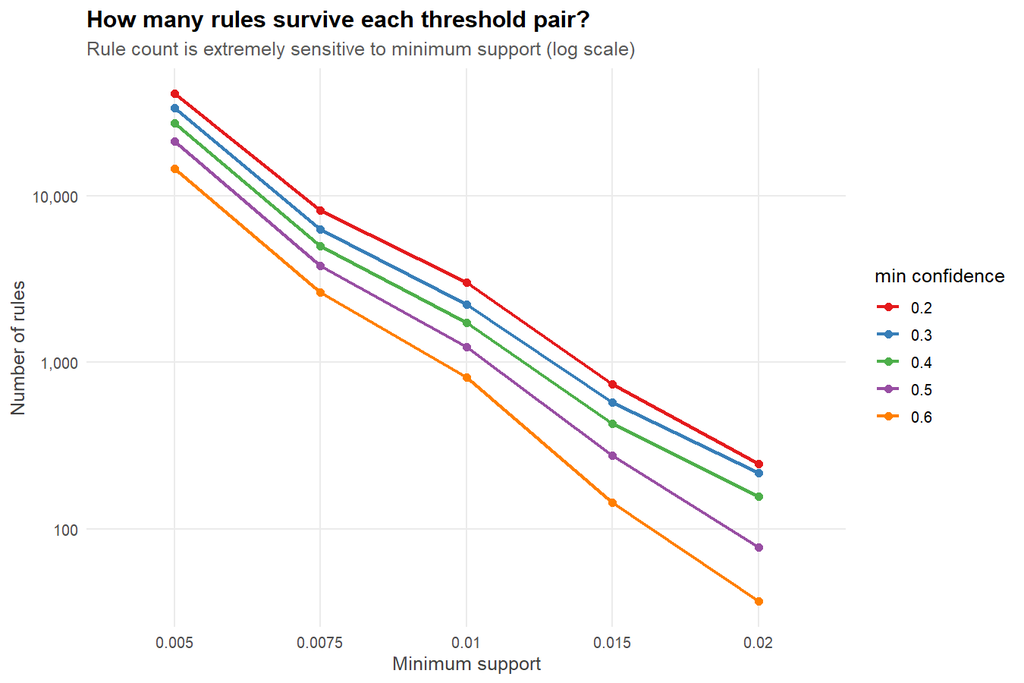

```r
fig("08_threshold_sensitivity")
```

```r
knitr::kable(tab("03_threshold_sensitivity"))
```

| support | confidence | n_rules |
| --- | --- | --- |
| 0.0050 | 0.2 | 40787 |
| 0.0075 | 0.2 | 8155 |
| 0.0100 | 0.2 | 3003 |
| 0.0150 | 0.2 | 740 |
| 0.0200 | 0.2 | 247 |
| 0.0050 | 0.3 | 33360 |
| 0.0075 | 0.3 | 6272 |
| 0.0100 | 0.3 | 2229 |
| 0.0150 | 0.3 | 577 |
| 0.0200 | 0.3 | 217 |
| 0.0050 | 0.4 | 27333 |
| 0.0075 | 0.4 | 4982 |
| 0.0100 | 0.4 | 1734 |
| 0.0150 | 0.4 | 429 |
| 0.0200 | 0.4 | 158 |
| 0.0050 | 0.5 | 21245 |
| 0.0075 | 0.5 | 3784 |
| 0.0100 | 0.5 | 1239 |
| 0.0150 | 0.5 | 277 |
| 0.0200 | 0.5 | 78 |
| 0.0050 | 0.6 | 14545 |
| 0.0075 | 0.6 | 2638 |
| 0.0100 | 0.6 | 814 |
| 0.0150 | 0.6 | 145 |
| 0.0200 | 0.6 | 37 |

Rule count falls roughly geometrically as minimum support rises — the practical reason support, not confidence, is the parameter to tune first. Confidence mostly trims an already-determined candidate pool.

# 6 Segment analysis

## 6.1 UK versus international

```r
knitr::kable(tab("05_segment_comparison"))
```

| Segment | Baskets | Products | MinSupport | Rules | MeanLift | MaxLift |
| --- | --- | --- | --- | --- | --- | --- |
| UK | 16506 | 3760 | 0.01 | 2661 | 13.13 | 72.66 |
| International | 1767 | 2778 | 0.02 | 375 | 9.84 | 37.25 |

```r
knitr::kable(head(tab("05_top_rules_international"), 10),
             caption = "Top international rules by lift")
```

Top international rules by lift

| Antecedent_LHS | Consequent_RHS | support | confidence | coverage | lift | count |
| --- | --- | --- | --- | --- | --- | --- |
| REGENCY TEA PLATE PINK | REGENCY TEA PLATE GREEN | 0.02094 | 0.94872 | 0.02207 | 37.25299 | 37 |
| REGENCY TEA PLATE GREEN | REGENCY TEA PLATE PINK | 0.02094 | 0.82222 | 0.02547 | 37.25299 | 37 |
| DOLLY GIRL CHILDRENS CUP + SPACEBOY CHILDRENS BOWL | DOLLY GIRL CHILDRENS BOWL | 0.02320 | 1.00000 | 0.02320 | 33.33962 | 41 |
| DOLLY GIRL CHILDRENS BOWL + SPACEBOY CHILDRENS CUP | DOLLY GIRL CHILDRENS CUP | 0.02151 | 1.00000 | 0.02151 | 32.72222 | 38 |
| PACK OF 20 SKULL PAPER NAPKINS | PACK OF 6 SKULL PAPER PLATES | 0.02151 | 0.84444 | 0.02547 | 31.08611 | 38 |
| PACK OF 6 SKULL PAPER PLATES | PACK OF 20 SKULL PAPER NAPKINS | 0.02151 | 0.79167 | 0.02716 | 31.08611 | 38 |
| PACK OF 6 SKULL PAPER PLATES | PACK OF 6 SKULL PAPER CUPS | 0.02377 | 0.87500 | 0.02716 | 30.31618 | 42 |
| PACK OF 6 SKULL PAPER CUPS | PACK OF 6 SKULL PAPER PLATES | 0.02377 | 0.82353 | 0.02886 | 30.31618 | 42 |
| POPPY’S PLAYHOUSE BEDROOM + POPPY’S PLAYHOUSE KITCHEN | POPPY’S PLAYHOUSE LIVINGROOM | 0.02037 | 0.75000 | 0.02716 | 29.45000 | 36 |
| PACK OF 20 SKULL PAPER NAPKINS | PACK OF 6 SKULL PAPER CUPS | 0.02151 | 0.84444 | 0.02547 | 29.25752 | 38 |

## 6.2 Seasonal shift

```r
knitr::kable(tab("05_season_comparison"))
```

| Season | Baskets | Rules | MeanLift |
| --- | --- | --- | --- |
| Pre-Christmas (Sep-Nov) | 6139 | 5174 | 11.70 |
| Rest of year | 12134 | 2296 | 13.38 |

```r
knitr::kable(head(tab("05_festive_only_rules"), 15),
             caption = "Rules that appear only in the September-November window")
```

Rules that appear only in the September-November window

| Antecedent_LHS | Consequent_RHS | support | confidence | coverage | lift | count |
| --- | --- | --- | --- | --- | --- | --- |
| DOLLY GIRL CHILDRENS CUP + SPACEBOY CHILDRENS BOWL | DOLLY GIRL CHILDRENS BOWL | 0.01010 | 0.95385 | 0.01059 | 57.40845 | 62 |
| BUTTON BOX + SUKI SHOULDER BAG | TOAST ITS - FAIRY FLOWER | 0.01010 | 0.73810 | 0.01368 | 54.59237 | 62 |
| BUTTON BOX + SUKI SHOULDER BAG | PIZZA PLATE IN BOX | 0.01026 | 0.75000 | 0.01368 | 49.50806 | 63 |
| DOLLY GIRL CHILDRENS BOWL + SPACEBOY CHILDRENS BOWL | DOLLY GIRL CHILDRENS CUP | 0.01010 | 0.83784 | 0.01205 | 48.98559 | 62 |
| PINK REGENCY TEACUP AND SAUCER + REGENCY TEA PLATE GREEN + REGENCY TEA PLATE ROSES | REGENCY TEA PLATE PINK | 0.01140 | 0.87500 | 0.01303 | 47.96094 | 70 |
| DOLLY GIRL CHILDRENS BOWL | DOLLY GIRL CHILDRENS CUP | 0.01352 | 0.81373 | 0.01662 | 47.57582 | 83 |
| DOLLY GIRL CHILDRENS CUP | DOLLY GIRL CHILDRENS BOWL | 0.01352 | 0.79048 | 0.01710 | 47.57582 | 83 |
| VINTAGE CHRISTMAS PAPER GIFT BAG | VINTAGE CHRISTMAS GIFT BAG LARGE | 0.01043 | 0.72727 | 0.01433 | 46.02812 | 64 |
| VINTAGE CHRISTMAS GIFT BAG LARGE | VINTAGE CHRISTMAS PAPER GIFT BAG | 0.01043 | 0.65979 | 0.01580 | 46.02812 | 64 |
| PINK REGENCY TEACUP AND SAUCER + REGENCY TEA PLATE GREEN | REGENCY TEA PLATE PINK | 0.01287 | 0.83158 | 0.01547 | 45.58092 | 79 |
| GREEN REGENCY TEACUP AND SAUCER + PINK REGENCY TEACUP AND SAUCER + REGENCY TEA PLATE ROSES | REGENCY TEA PLATE PINK | 0.01108 | 0.82927 | 0.01336 | 45.45427 | 68 |
| SUKI SHOULDER BAG + TOAST ITS - FAIRY FLOWER | BUTTON BOX | 0.01010 | 0.89855 | 0.01124 | 44.48551 | 62 |
| PINK REGENCY TEACUP AND SAUCER + REGENCY TEA PLATE ROSES + ROSES REGENCY TEACUP AND SAUCER | REGENCY TEA PLATE PINK | 0.01124 | 0.80233 | 0.01401 | 43.97747 | 69 |
| PIZZA PLATE IN BOX + SUKI SHOULDER BAG | BUTTON BOX | 0.01026 | 0.87500 | 0.01173 | 43.31956 | 63 |
| PINK REGENCY TEACUP AND SAUCER + REGENCY TEA PLATE ROSES | REGENCY TEA PLATE PINK | 0.01238 | 0.77551 | 0.01596 | 42.50765 | 76 |

The festive quarter yields substantially more rules from *fewer* baskets — gift buying is more patterned than routine buying. Rules that exist only in this window are the ones worth building seasonal campaigns around.

# 7 From rules to action

## 7.1 A rule-based recommender

```r
knitr::kable(tab("05_recommender_demo"))
```

| Invoice | Basket | Recommendation | Confidence | Lift | Support |
| --- | --- | --- | --- | --- | --- |
| 553525 | HANGING HEART JAR T-LIGHT HOLDER \| FILIGRIS HEART WITH BUTTERFLY \| PAINTED METAL PEARS ASSORTED \| IVORY HANGING DECORATION HEART \| HANGING CHICK GREEN DECORATION \| HANGING CHICK CREAM DECORATION … | ASSORTED COLOUR BIRD ORNAMENT | 0.700 | 8.80 | 0.0142 |
| 553525 | HANGING HEART JAR T-LIGHT HOLDER \| FILIGRIS HEART WITH BUTTERFLY \| PAINTED METAL PEARS ASSORTED \| IVORY HANGING DECORATION HEART \| HANGING CHICK GREEN DECORATION \| HANGING CHICK CREAM DECORATION … | WHITE HANGING HEART T-LIGHT HOLDER | 0.391 | 3.18 | 0.0112 |
| 577487 | HANGING JAM JAR T-LIGHT HOLDER \| SET OF 6 TEA TIME BAKING CASES \| SET OF 12 FAIRY CAKE BAKING CASES \| MAGIC DRAWING SLATE DOLLY GIRL \| ROUND SNACK BOXES SET OF 4 FRUITS | SET OF 6 SNACK LOAF BAKING CASES | 0.549 | 28.34 | 0.0113 |
| 577487 | HANGING JAM JAR T-LIGHT HOLDER \| SET OF 6 TEA TIME BAKING CASES \| SET OF 12 FAIRY CAKE BAKING CASES \| MAGIC DRAWING SLATE DOLLY GIRL \| ROUND SNACK BOXES SET OF 4 FRUITS | SET OF 12 MINI LOAF BAKING CASES | 0.610 | 25.11 | 0.0126 |
| 577487 | HANGING JAM JAR T-LIGHT HOLDER \| SET OF 6 TEA TIME BAKING CASES \| SET OF 12 FAIRY CAKE BAKING CASES \| MAGIC DRAWING SLATE DOLLY GIRL \| ROUND SNACK BOXES SET OF 4 FRUITS | ROUND SNACK BOXES SET OF4 WOODLAND | 0.531 | 13.26 | 0.0169 |

Given a partial basket, every rule whose antecedent is fully contained in it “fires”; the consequents the customer has not already taken, ranked by lift, are the recommendations. This is a complete cold-start-free recommender that needs no customer history at all — only the current basket.

## 7.2 Quantified opportunity

For each rule, the baskets containing the antecedent but *missing* the consequent are counted directly from support and coverage — no basket scan needed, since coverage is $\text{supp}(X)$ and support is $\text{supp}(X \cup Y)$:

$$\text{missed baskets} = \big(\text{coverage} - \text{support}\big)
\times N$$

Multiplying by the rule’s confidence and the consequent’s average line value gives an order-of-magnitude estimate of the revenue a well-placed cross-sell prompt could recover.

```r
knitr::kable(head(tab("05_cross_sell_opportunity_value"), 15))
```

| Rule | Consequent | Support | Confidence | Lift | MissedBaskets | AvgPrice | AvgQty | ExpectedUplift | PotentialRevenue |
| --- | --- | --- | --- | --- | --- | --- | --- | --- | --- |
| {ROSES REGENCY TEACUP AND SAUCER} => {REGENCY CAKESTAND 3 TIER} | REGENCY CAKESTAND 3 TIER | 0.02873 | 0.494 | 4.60 | 537 | 13.979725 | 6.640204 | 265 | 24625.28 |
| {GREEN REGENCY TEACUP AND SAUCER} => {REGENCY CAKESTAND 3 TIER} | REGENCY CAKESTAND 3 TIER | 0.02786 | 0.502 | 4.67 | 504 | 13.979725 | 6.640204 | 253 | 23486.28 |
| {JUMBO BAG RED RETROSPOT} => {JUMBO BAG PINK POLKADOT} | JUMBO BAG PINK POLKADOT | 0.04515 | 0.398 | 5.98 | 1248 | 2.606036 | 17.267270 | 497 | 22351.25 |
| {LUNCH BAG RED RETROSPOT} => {JUMBO BAG RED RETROSPOT} | JUMBO BAG RED RETROSPOT | 0.03169 | 0.370 | 3.26 | 985 | 2.493917 | 22.196816 | 364 | 20174.87 |
| {SET OF 3 REGENCY CAKE TINS} => {REGENCY CAKESTAND 3 TIER} | REGENCY CAKESTAND 3 TIER | 0.01686 | 0.354 | 3.30 | 561 | 13.979725 | 6.640204 | 199 | 18435.13 |
| {GREEN REGENCY TEACUP AND SAUCER,ROSES REGENCY TEACUP AND SAUCER} => {REGENCY CAKESTAND 3 TIER} | REGENCY CAKESTAND 3 TIER | 0.02233 | 0.532 | 4.95 | 359 | 13.979725 | 6.640204 | 191 | 17729.08 |
| {PINK REGENCY TEACUP AND SAUCER} => {REGENCY CAKESTAND 3 TIER} | REGENCY CAKESTAND 3 TIER | 0.02145 | 0.516 | 4.80 | 368 | 13.979725 | 6.640204 | 190 | 17626.97 |
| {JUMBO BAG VINTAGE DOILY} => {JUMBO BAG RED RETROSPOT} | JUMBO BAG RED RETROSPOT | 0.03158 | 0.469 | 4.14 | 653 | 2.493917 | 22.196816 | 306 | 16953.47 |
| {WOODLAND CHARLOTTE BAG} => {REGENCY CAKESTAND 3 TIER} | REGENCY CAKESTAND 3 TIER | 0.01423 | 0.312 | 2.91 | 572 | 13.979725 | 6.640204 | 178 | 16566.50 |
| {SPOTTY BUNTING} => {PARTY BUNTING} | PARTY BUNTING | 0.02643 | 0.423 | 4.63 | 659 | 5.809162 | 10.131138 | 279 | 16405.80 |
| {JUMBO SHOPPER VINTAGE RED PAISLEY} => {JUMBO BAG RED RETROSPOT} | JUMBO BAG RED RETROSPOT | 0.03721 | 0.579 | 5.11 | 494 | 2.493917 | 22.196816 | 286 | 15833.55 |
| {JUMBO STORAGE BAG SUKI} => {JUMBO BAG RED RETROSPOT} | JUMBO BAG RED RETROSPOT | 0.03962 | 0.611 | 5.39 | 460 | 2.493917 | 22.196816 | 281 | 15558.64 |
| {LUNCH BAG SUKI DESIGN} => {JUMBO BAG RED RETROSPOT} | JUMBO BAG RED RETROSPOT | 0.02216 | 0.316 | 2.78 | 878 | 2.493917 | 22.196816 | 277 | 15358.69 |
| {JUMBO BAG RED RETROSPOT} => {JUMBO STORAGE BAG SUKI} | JUMBO STORAGE BAG SUKI | 0.03962 | 0.349 | 5.39 | 1349 | 2.750735 | 11.496622 | 471 | 14888.68 |
| {JUMBO BAG PINK POLKADOT} => {JUMBO BAG RED RETROSPOT} | JUMBO BAG RED RETROSPOT | 0.04515 | 0.678 | 5.98 | 391 | 2.493917 | 22.196816 | 265 | 14675.03 |

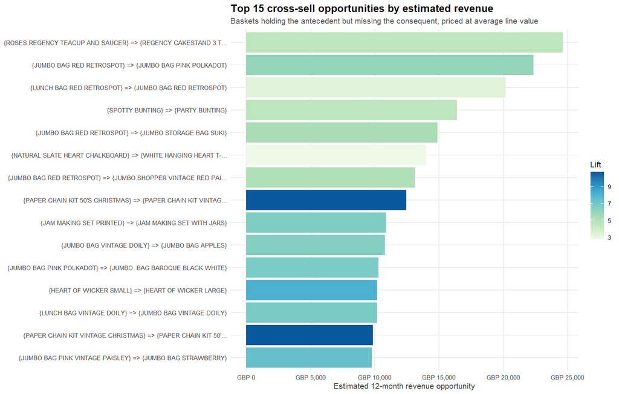

```r
fig("15_cross_sell_opportunity_value")
```

```r
val  <- tab("05_cross_sell_opportunity_value")
best <- tab("05_cross_sell_best_rule_per_product")

gbp <- function(x) paste0("GBP ", formatC(round(x), format = "d", big.mark = ","))

knitr::kable(data.frame(
  Basis = c("Naive sum over all rules",
            "Best rule per consequent product",
            "Top 20 products of those",
            "Actual revenue in the period"),
  Estimate = gbp(c(sum(val$PotentialRevenue,  na.rm = TRUE),
                   sum(best$PotentialRevenue, na.rm = TRUE),
                   sum(head(best, 20)$PotentialRevenue, na.rm = TRUE),
                   sum(retail$Revenue))),
  Note = c("Double counts -- upper bound only",
           "Defensible headroom estimate",
           "Where to start",
           "For scale")))
```

| Basis | Estimate | Note |
| --- | --- | --- |
| Naive sum over all rules | GBP 7,553,161 | Double counts – upper bound only |
| Best rule per consequent product | GBP 1,017,501 | Defensible headroom estimate |
| Top 20 products of those | GBP 255,319 | Where to start |
| Actual revenue in the period | GBP 9,658,813 | For scale |

Summing across all 2215 rules badly double counts: many rules share a consequent and fire on the same basket. Keeping only the single best rule per consequent product collapses them to 238 distinct opportunities and gives the defensible figure — roughly 11% of realised revenue in the period.

Note that the biggest opportunities are **not** the highest-lift rules. The herb marker rules that top the lift table are worth a few hundred pounds each, because the products are cheap and the sets are already almost always bought complete. The money is in mid-lift, high-support rules on expensive items — `ROSES REGENCY TEACUP AND SAUCER ⇒ REGENCY CAKESTAND 3 TIER` has a lift of only 4.6, but it fires on hundreds of baskets and the cakestand is a high-ticket product. **Lift finds the pattern; support and price decide whether it is worth acting on.**

# 8 Findings and recommendations

**1. Products sell as families, not as individuals.** Nearly every high-lift rule links members of one product set — herb markers, the regency tea range, the retrospot lunch bags, the woodland/spaceboy children’s line. Lift values of 50–75× are enormous, and mean a customer holding two herb markers is overwhelmingly likely to be completing the set.

*Action:* sell and merchandise these as bundles. A “complete the set” prompt on the product page is the single highest-value intervention this analysis supports, and the rules identify exactly which sets qualify.

**2. Colourway substitution is real and predictable.** Rules link the same product in different colours (red / pink / blue retrospot bags, white / red hanging heart holders). Customers buying one variant frequently buy another.

*Action:* show the colour family, not just the SKU, and keep variants in stock together — a stock-out on one variant depresses sales of the whole cluster.

**3. High confidence without lift is a trap.** Rules ending in `WHITE HANGING HEART T-LIGHT HOLDER` reach high confidence simply because it appears in over 12% of all baskets. Lift corrects for this, which is why it was used as the primary ranking measure throughout.

*Action:* never rank recommendations on confidence alone.

**4. Association structure is seasonal.** Thousands of rules exist only in the September–November window.

*Action:* re-mine the rules quarterly rather than treating the rule set as static, and hold separate rule sets for the festive campaign.

**5. Segment the model.** UK and international baskets have measurably different association structures. A single global rule set serves neither well.

*Action:* maintain per-segment rule sets, at minimum UK versus international.

## 8.1 Limitations

- **Wholesale contamination.** Very large baskets are wholesale orders, not consumer shopping. They inflate co-occurrence counts. A production system should mine consumer and wholesale baskets separately.
- **Correlation, not causation.** A rule says two products appear together; it does not prove that promoting one *causes* the other to sell. Validation requires an A/B test.
- **One year of data.** Trend versus seasonality cannot be separated from a single annual cycle.
- **Missing `CustomerID` on ~25% of rows** prevents customer-level basket analysis, so this study is purely transaction-level.
- **Support floor hides the long tail.** At 1% support, products selling fewer than ~183 baskets a year can never enter a rule, however strong their associations are. Niche cross-sells are invisible to this model.

## 8.2 Possible extensions

- **FP-Growth** (`arules::fim4r` or `rCBA`) for a runtime comparison against Apriori on the same data.
- **Sequential pattern mining** (`arulesSequences`, cSPADE) using `CustomerID` and `InvoiceDate` to find what customers buy *next*, not just *together*.
- **Product hierarchies** — aggregating SKUs into categories would lift support values enough to reveal cross-category rules the SKU-level model misses.
- **Negative association rules** — which products *suppress* each other, useful for detecting cannibalisation between variants.

# 9 References

Agrawal, R. & Srikant, R. (1994). *Fast Algorithms for Mining Association Rules*. Proceedings of the 20th VLDB Conference, 487–499.

Chen, D., Sain, S. L. & Guo, K. (2012). *Data mining for the online retail industry*. Journal of Database Marketing & Customer Strategy Management, 19(3), 197–208.

Hahsler, M., Grün, B. & Hornik, K. (2005). *arules — A Computational Environment for Mining Association Rules and Frequent Item Sets*. Journal of Statistical Software, 14(15).

Hahsler, M. & Chelluboina, S. (2011). *Visualizing Association Rules: Introduction to the R-extension Package arulesViz*.

Dua, D. & Graff, C. UCI Machine Learning Repository, dataset 352: *Online Retail*. https://archive.ics.uci.edu/dataset/352/online+retail